# Snapshot and summary of soil testing outputs

Jackie Ouzman

08 September, 2021

## Number of N and P trials for 2020 -2021 season

CSIRO team have been supplied with spatial data for the location of strip trials. Along with this information we have details on the type of trial (either N or P) and the fertilisers used.

At the date of this report the below graphs reflect the trials for the 2020 - 2021 season.

Note that a few paddocks have both N and P trials (this has been captured in the below graphs).

The below graphs are the number of paddocks in the projcet.

Most paddocks have two zone, but some have just one and some have multiple zone.

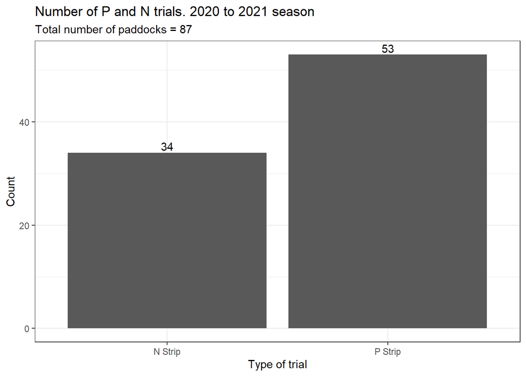

| Paddock_ID | organisati | contact | farmer | paddock | NoAnalysis |
| --- | --- | --- | --- | --- | --- |
| 52325 | FSG | EPARF | Kuhlmann | 100 | NA |
| 52322 | FSG | EPARF | Kuhlmann | 26 | NA |
| 52324 | FSG | EPARF | Kuhlmann | 33 | NA |
| 52321 | FSG | EPARF | Kuhlmann | 8 | NA |
| 52356 | FSG | EPARF | Matthews | 2 | Different seeding rate for grain (see comments field) |
| 52341 | FSG | EPARF | Polkinghorne | Cattle_Yards | Overlapping treatements, and Zone miss-alignment |
| 52214 | FSG | Hart | Clarke | Fosters | NA |
| 52223 | FSG | Hart | Johns | Tillers | No Rates or Yields |
| 52224 | FSG | Hart | Johns | Youngs | No Rates or Yields |
| 52232 | FSG | Hart | Ottens | Pdk_6_North | The strips were missed completely due to a miscommunication at seeding. |
| 52241 | FSG | Hart | Sommerville | Barn | NA |
| 52244 | FSG | Hart | Sommerville | Kellocks_Hut | NA |
| 52251 | FSG | Hart | Williams | pdk42 | No Yield Points |
| 52253 | FSG | Hart | Williams | Pdk53 | Lack of Yield Points |
| 52453 | FSG | MSF_Frontier_Farming | Hards | Francis | NA |
| 524102 | FSG | MSF_Frontier_Farming | Pole | Gums | Not Required |
| 524101 | FSG | MSF_Frontier_Farming | Pole | Symes | NA |
| 51611 | Nutrien | Claire_Gutsche | Lister_Trading | Aldermans | Switched GSP & ALT GSP due to Miss-alignment of Yield points |
| 51615 | Nutrien | Claire_Gutsche | Lister_Trading | Homestead_Home | No Yield |
| 51613 | Nutrien | Claire_Gutsche | Lister_Trading | Stewies | NA |
| 51711 | Nutrien | Hamish_Verco | Ballinger_Bros | H5 | No Yield |
| 31622 | Nutrien | Kris_Dixon | K_G_Bird | JG320 | no starter fertiliser went out in one of the treatments |
| 31713 | Nutrien | Matt_Nihill | Weeks | South_of_House | NA |
| 51412 | Nutrien | Paul_Ackland | Limevale | Back_Kitto | NA |
| 51421 | Nutrien | Paul_Ackland | MA_Thompson | Bells_3 | No trial data. Three quarters of the trial area was cut for hay. |
| 51911 | Nutrien | Tom_Cooper | AP_Robertson | Hoffes | No Yield in Zones |
| 51102 | Nutrien | Zac_Richardson | LS_EE_Harris | North_Race_3 | No Yield |

The status for the paddocks we have spatial data for.

Unique paddock code and strip type displayed. This is NOT zones!

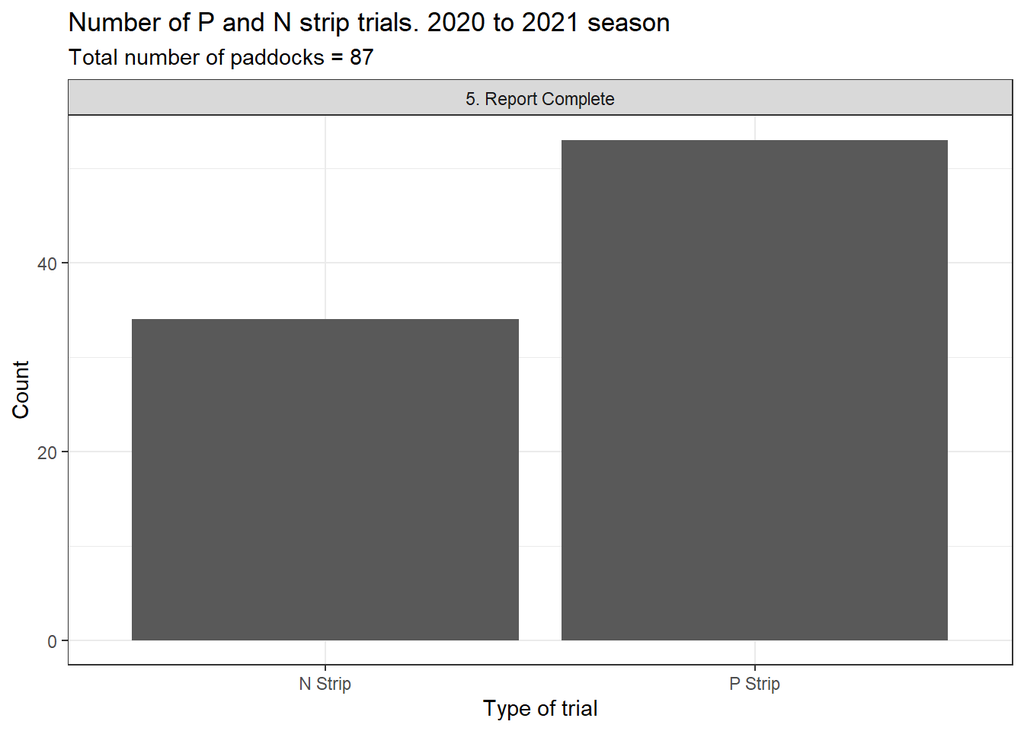

Status

n

5. Report Complete

87

For the done reports how many zones?

This is distinct for paddock ID and trial type.

This will capture zones in paddocks that are included in both N and P trials.

Most of them are P strips.

| Strip_Type | n |
| --- | --- |
| N Strip | 34 |
| P Strip | 53 |

## Fertiliser strips implemented

In each paddocks fertiliser strips were implemented by the growers.

The fertiliser rate of these strips we intended to reflect how fertilser practices would change as a results of a soil test.

Each paddock had soil test taken for N and P per zone (often 2 zones per paddock).

**Need to add more details here….**

Using the soil test results a recommended fertiliser rate can be derived.

**Sean has now supplied this 18/02/2021 and more notes will be added to this**

However this recommend rate did not translate what was implemented in the fertiliser trials.

Instead the strip rates of the trials were often decided in collaboration between the grower and consultant.

What the project ended up with was a number of strips that were different to the growers standard practice.

A common scenario was;

- 1/2 the growers rate
- double the growers rate
- strip that reflected the growers rate.

Other scenario include:

- zero strip
- 2 rates lower than GSP
- 2 rates higher than GSP

In the first season of data collection, we identified the growers standard practice and compared the fertiliser strips to this.

We reported if the strip rate was significantly different to the GSP.

We did this comparison in each zone for the paddock.

More details on this is below sections.

## Number of strips per paddock

For some paddocks / growers variable fertiliser rate is common practice. In these paddocks it is difficult to represent the growers standard practice, as it changes through the paddock.

**Note** that the grouping called ‘Alt GPS’ contains 2 strips that reflect the growers standard practice, and the grouping called ‘no alt GPS’ only contains one strip that reflect the growers standard practice.

I have created a new clm to adjusts this values.

Note that some padocks included in this plot are ‘pending edits’, we have not yet confirmed the strips locations, zone, or fertiliser rates.

This means that the final plot when all the data is finalised will look slightly different to the below one.

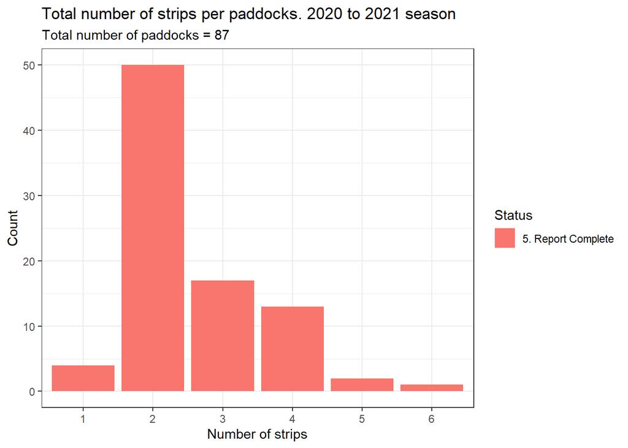

## Alternative GSP

The results in the first season were surprising.

Higher rates of fertiliser did not always equate to higher yields.

This may occur for many reasons:

- poor location of the strips.
- mismatch between the strips and the yield monitor data.
- small sample size e.g. the number of yield points per strip and zone.
- large variation in the soil type.
- edge effect of the strips.
- low rates of fertiliser applied (e.g. too little to see a strong yield response).

However despite these wide range of reasons it was thought that yield variation is was driving these observations.

In order to better understand the yield variation of the paddocks, we identified an extra strip to reflect the growers standard practice.

We aim to use the two strips that represent the growers standard practice to quantify yield variability. This analysis will be undertaken at a later date and may be used to filter data which will be included in the economic analysis.

In some paddocks we cannot identify an additional strip to reflect the Alt GSP. The below graphs reflect the numbers.

How many of the zones were analysed for alternative GSP?

| comparison | n |
| --- | --- |
| GSP_v_AltGSP | 115 |
| NA | 76 |

Ideally the yield would be the same in both strips (GSP and Alt GSP), and / or the yield would not be significantly different.

Significant yield differences between the two strips suggest that there is a high degree of variability between the two strip that were applied with the same fertiliser.

This may occur because the strips have underlying soil, plant growth conditions.

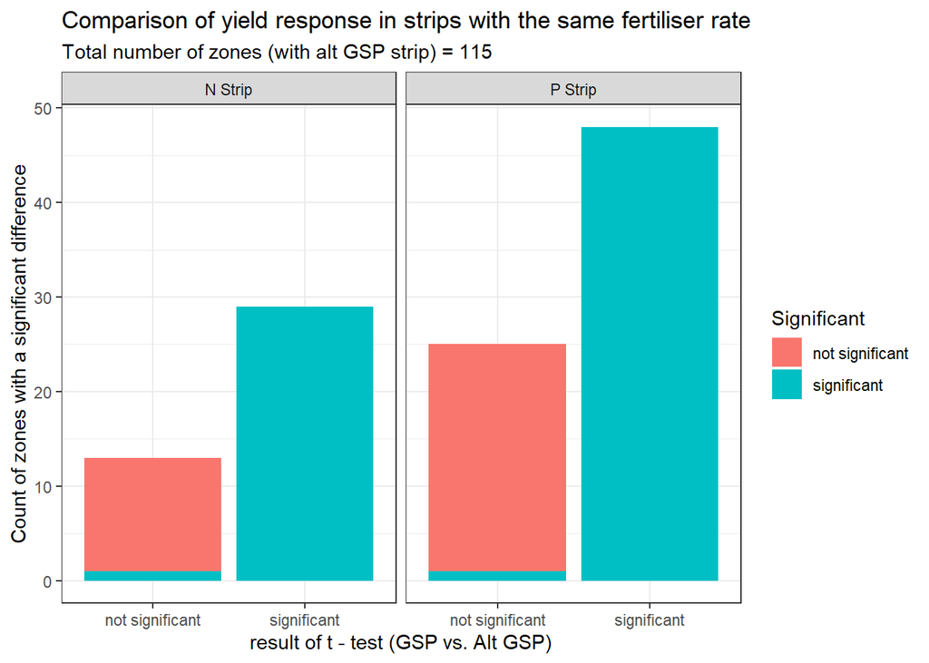

| Zone ID | Mean yield difference | Significant |
| --- | --- | --- |
| 331111 | 3.58 | significant |
| 331110 | 2.95 | significant |
| 311230 | 2.31 | significant |
| 311231 | 1.76 | significant |
| 317421 | 1.64 | significant |
| 317220 | 1.61 | significant |
| 522160 | 1.54 | significant |
| 321361 | 1.53 | significant |
| 317221 | 1.32 | significant |
| 321122 | 1.24 | significant |
| 522161 | 1.14 | significant |
| 317131 | 1.11 | significant |
| 317111 | 1.10 | significant |
| 535411 | 1.04 | significant |
| 317261 | 1.00 | significant |
| 516131 | 0.98 | significant |
| 522411 | 0.98 | significant |
| 317130 | 0.97 | significant |
| 321112 | 0.91 | significant |
| 311110 | 0.81 | significant |
| 331420 | 0.81 | significant |
| 317350 | 0.76 | significant |
| 522440 | 0.72 | significant |
| 317450 | 0.71 | significant |
| 311330 | 0.70 | significant |
| 316210 | 0.70 | significant |
| 311220 | 0.69 | significant |
| 522441 | 0.67 | significant |
| 317330 | 0.65 | significant |
| 321442 | 0.64 | significant |

[output cut: 85 more lines]

## Rainfall

The cost of fertiliser is reflected by the rainfall zone.

We have used the location of the trials to derive and average rainfall.

** See code - for more details **

The rainfall is assigned to rainfall class

- low rainfall <= 350 mm
- medium rainfall between 350 to 500 mm
- high rainfall > 500 mm

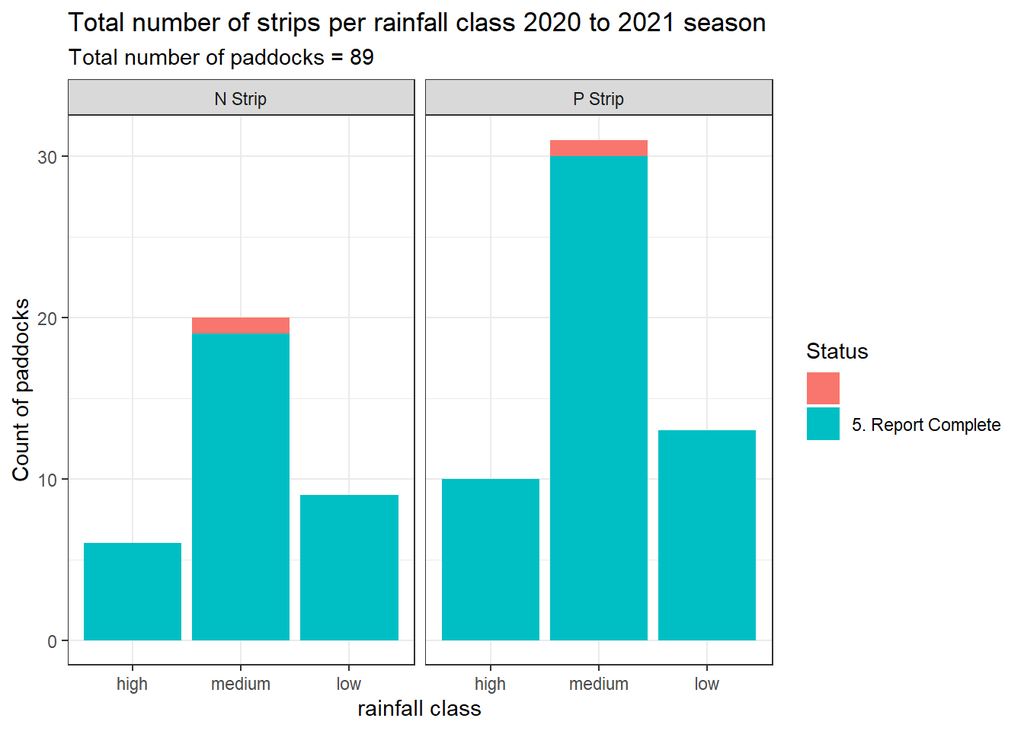

## Fertiliser products and rates

The fertiliser that was applied in each strip was confirmed with a pre harvest map.

** could include a pre harvest map **

The fertiliser product and rates applied are converted to N or P content for each strip in the project. The below code is a check of what products have been applied in a N and P trial

Note that some products are placeholders and more information will follow. For example ‘no strip’ or ‘double’ means that the product and or rate have not been supplied yet.

Another note is the product applied in the strip may not reflect the nature of the strip trial. In the strips both N and P products have often been applied. The below code and process we are requesting all products applied in the strips.

Other products applied as a started and or topdress have also been captured. At this stage Therese doesn’t want this included in the calculations for total N or P applied.

The below products are only for sites where the report is complete (this is just a filter and can be changed easily).

### Products applied in N trials

| product |
| --- |
| urea |
| king mix |
| NA |
| granulock zs 24-11-0-6 |
| soa/urea |
| granulock z |
| urea/soa 60/40 |
| uan |

### Products applied in P trials

| product |
| --- |
| granulock z |
| NA |
| urea |
| granuloc z |
| dap |
| map/soa 14:15:0:9 |
| dap / urea 28-13-0-1 |
| granulock zs 24-11-0-6 |
| urea / map 27:12 |
| map |
| prime msz |
| granulock |
| uan |
| mesz |
| zincguard d2 |
| 24:16 |
| meszn n12; p17.5; k0; zn10 |

### How much N was applied in the strips?

Summary stats on how much N was applied in the strips. Note I have removed the ‘Alt GSP’ from this analysis.

This is just for sites / strips that the report is complete.

| rainfall_class | maximum N applied | minimum N applied | mean N applied | median N applied | count |
| --- | --- | --- | --- | --- | --- |
| high | 413 | 7 | 149 | 134 | 20 |
| medium | 224 | 3 | 91 | 79 | 54 |
| low | 87 | 0 | 38 | 40 | 35 |

| rainfall_class | count strips with zero rate |
| --- | --- |
| low | 3 |

## How much P was applied.

Summary stats on how much P was applied in the strips. Note I have removed the ‘Alt GSP’ from this analysis.

The results may reflect the trial design, not all paddocks had a zero strip (P applied = 0). There are more strips with zero P applied in the medium rainfall zone, than in the high or low rainfall zone.

This is just for sites / strips that the report is complete.

| rainfall_class | maximum P applied | minimum P applied | mean P applied | median P applied | count |
| --- | --- | --- | --- | --- | --- |
| high | 40 | 0 | 13 | 14 | 31 |
| medium | 40 | 0 | 13 | 13 | 99 |
| low | 35 | 0 | 10 | 8 | 45 |

| rainfall_class | count strips with zero rate |
| --- | --- |
| high | 10 |
| medium | 22 |
| low | 10 |

## Summary of spatial data

This data is a summary of what paddocks implemented a N or P fertiliser trial. For these paddocks, we were given spatial data that allowed us to create maps. These pre harvest map contain:

- location of strips in paddock
- location of zone (zones are location that the soil sampling was done)
- legends which indicate how much fertiliser was applied (product and rate)

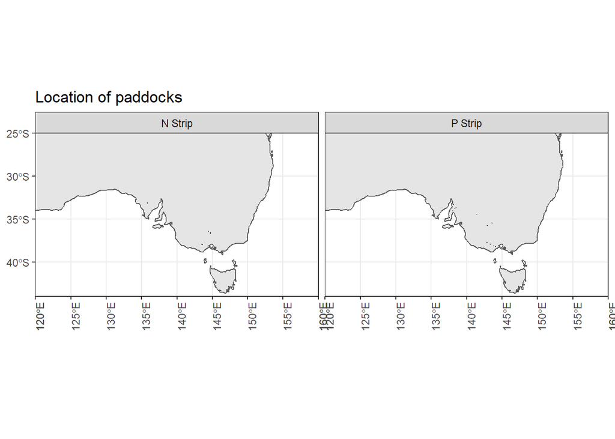

## Yield response to fertilisers application (high medium low rates)

Different comparisons are made between fertilisers strips for each zone.

Comparison of yield response in the strip / zone per zone between:

- High fertiliser rate vs low fertiliser rate (yield for high fert rate - yield for low fert rate)
- High fertiliser rate vs medium fertiliser rate (yield for high fert rate - yield for medium fert rate)
- Medium fertiliser rate vs low fertiliser rate (yield for medium fert rate - yield for low fert rate)

The yield response is classed as ‘positive’ when higher rates of fertiliser results in higher yields

The yield response is classed as ‘no response’ when higher rates of fertiliser results in no change in yields (this is defined as 0 +/- standard error)

The yield response is classed as ‘negative’ when higher rates of fertiliser results in lower yields.

T- test was also run for each comparison and the significant differences at p < 0.05 reported. Note that some significant values are not reported for the zone, this may occur when there is not enough data points to run the t - test (although there is still have yield values to make a comparison).

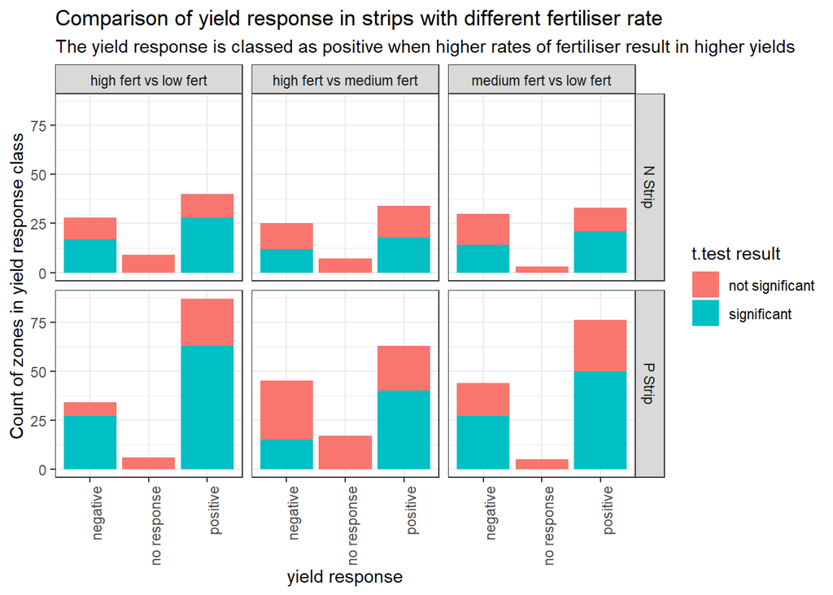

### High fertiliser rate vs low fertiliser rate.

| Zone ID | Mean yield difference | yield response | Significant |
| --- | --- | --- | --- |
| 311110 | 0.32 | negative | significant |
| 311111 | 0.62 | negative | significant |
| 311150 | 1.17 | positive | significant |
| 311151 | 0.07 | no_response | not significant |
| 311220 | 0.45 | negative | significant |
| 311221 | 0.72 | negative | significant |
| 311230 | 0.65 | negative | significant |
| 311231 | 0.07 | no_response | not significant |
| 311330 | 0.87 | positive | significant |
| 311331 | 0.94 | positive | significant |
| 311360 | 0.21 | negative | significant |
| 311361 | 0.26 | negative | significant |
| 311520 | 0.80 | negative | significant |
| 311521 | 1.24 | positive | significant |
| 312110 | 0.53 | positive | significant |
| 312111 | 0.20 | positive | significant |
| 312140 | 0.14 | positive | significant |
| 312141 | 0.10 | positive | not significant |
| 312150 | 0.10 | positive | not significant |
| 312151 | 0.01 | no_response | not significant |
| 312160 | 0.13 | negative | significant |
| 312161 | 0.08 | positive | not significant |
| 312220 | 0.17 | positive | significant |
| 312221 | 0.35 | positive | significant |
| 312230 | 0.32 | negative | not significant |
| 312231 | 1.16 | positive | significant |
| 312240 | 0.50 | positive | significant |
| 312241 | 0.26 | positive | not significant |
| 316110 | 0.25 | negative | significant |
| 316111 | 0.17 | negative | not significant |

[output cut: 174 more lines]

### High fertiliser rate vs medium fertiliser rate.

| Zone ID | Mean yield difference | yield response | Significant |
| --- | --- | --- | --- |
| 311110 | 0.07 | positive | not significant |
| 311111 | 0.45 | negative | significant |
| 311150 | 0.72 | positive | significant |
| 311151 | 0.15 | negative | significant |
| 311220 | 0.35 | negative | not significant |
| 311221 | 0.19 | negative | not significant |
| 311230 | 2.27 | positive | significant |
| 311231 | 1.31 | positive | significant |
| 311330 | 0.57 | positive | significant |
| 311331 | 0.26 | positive | not significant |
| 311360 | 0.53 | negative | significant |
| 311361 | 0.08 | no_response | not significant |
| 311520 | 0.05 | negative | not significant |
| 311521 | 0.75 | positive | significant |
| 312110 | 0.44 | positive | significant |
| 312111 | 0.14 | positive | not significant |
| 312140 | 0.05 | negative | not significant |
| 312141 | 0.26 | negative | significant |
| 312150 | 0.17 | negative | significant |
| 312151 | 0.09 | positive | not significant |
| 312160 | 0.17 | negative | not significant |
| 312161 | 0.02 | no_response | not significant |
| 312220 | 0.18 | positive | not significant |
| 312221 | 0.07 | negative | not significant |
| 312230 | 0.57 | positive | significant |
| 312231 | 0.44 | positive | significant |
| 312240 | 0.10 | positive | not significant |
| 312241 | 0.24 | negative | significant |
| 316110 | 0.03 | negative | not significant |
| 316111 | 0.04 | negative | not significant |

[output cut: 161 more lines]

## Medium fertiliser rate vs low fertiliser rate.

| Zone ID | Mean yield difference | yield response | Significant |
| --- | --- | --- | --- |
| 311110 | 0.38 | negative | significant |
| 311111 | 0.17 | negative | not significant |
| 311150 | 0.45 | positive | significant |
| 311151 | 0.22 | positive | significant |
| 311220 | 0.10 | negative | not significant |
| 311221 | 0.53 | negative | significant |
| 311230 | 2.92 | negative | significant |
| 311231 | 1.44 | negative | significant |
| 311330 | 0.30 | positive | significant |
| 311331 | 0.68 | positive | significant |
| 311360 | 0.31 | positive | significant |
| 311361 | 0.30 | negative | not significant |
| 311520 | 0.75 | negative | significant |
| 311521 | 0.49 | positive | significant |
| 312110 | 0.09 | positive | not significant |
| 312111 | 0.06 | positive | not significant |
| 312140 | 0.19 | positive | significant |
| 312141 | 0.36 | positive | significant |
| 312150 | 0.27 | positive | significant |
| 312151 | 0.08 | negative | not significant |
| 312160 | 0.04 | positive | not significant |
| 312161 | 0.07 | positive | not significant |
| 312220 | 0.07 | negative | not significant |
| 312221 | 0.41 | positive | significant |
| 312230 | 0.88 | negative | significant |
| 312231 | 0.84 | positive | significant |
| 312240 | 0.39 | positive | significant |
| 312241 | 0.50 | positive | significant |
| 316110 | 0.22 | negative | significant |
| 316111 | 0.13 | negative | not significant |

[output cut: 161 more lines]

## An altertaive way to show the yield resposne high, medium and low fertiliser rates.

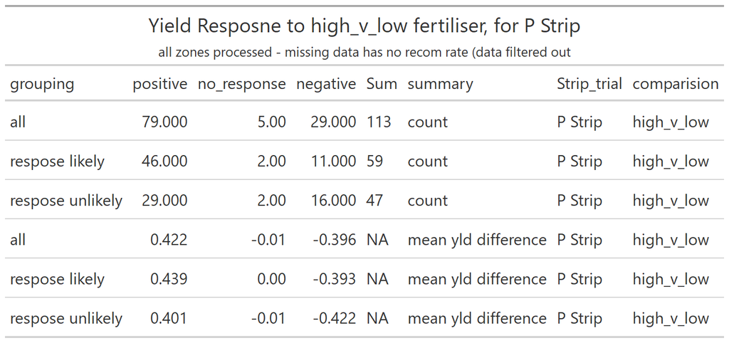

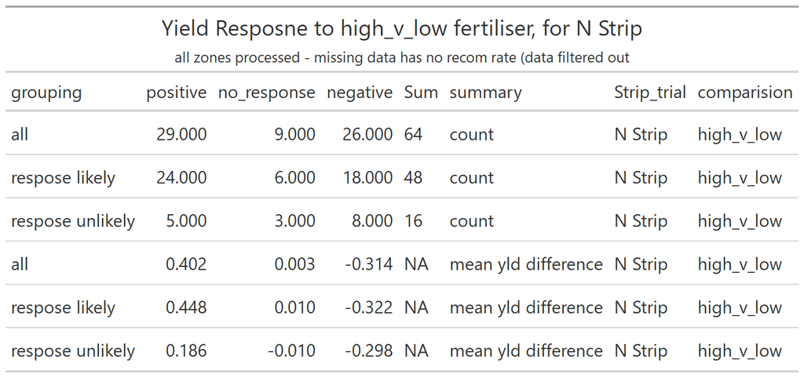

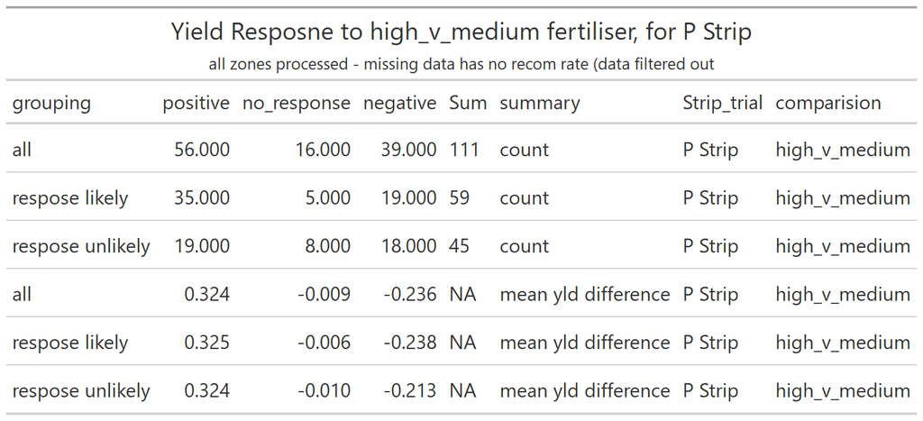

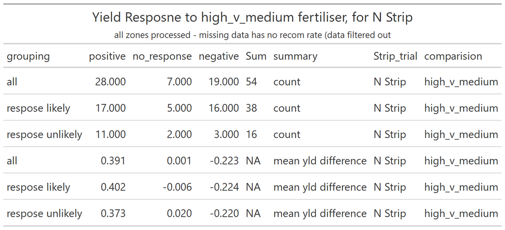

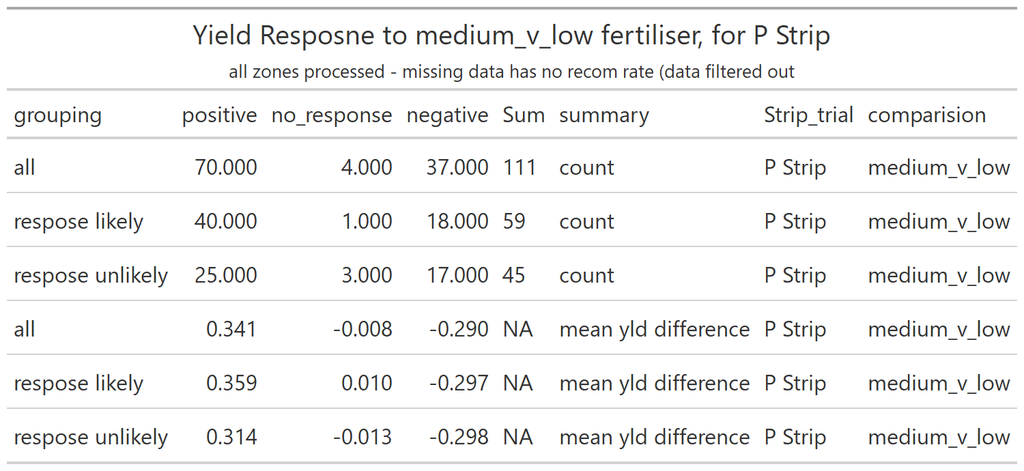

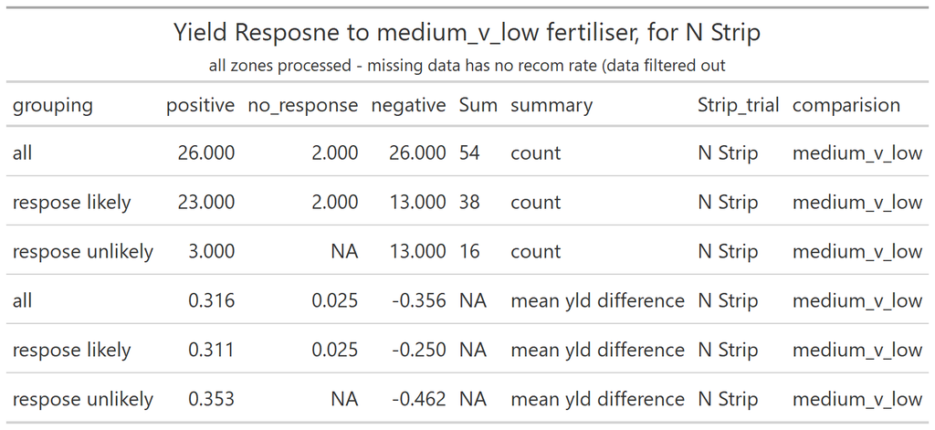

## Yield response to fertilisers application (growers rates compared to other rates)

Different comparisons are made between the growers standard practice and fertilisers strips for each zone.

Comparison of yield response in the strip / zone per paddock between:

- Growers standard practice GSP vs low fertiliser rate (yield for GSP fert rate - yield for low fert rate)
- Growers standard practice GSP fertiliser rate vs high fertiliser rate (yield for GSP fert rate - yield for high fert rate)

The yield response is classed as ‘positive’ when higher rates of fertiliser results in higher yields

The yield response is classed as ‘no response’ when higher rates of fertiliser results in no change in yields (this is defined as 0 +/- standard error)

The yield response is classed as ‘negative’ when higher rates of fertiliser results in lower yields.

T- test was also run for each comparison and the significant differences at p < 0.05 reported. Note that some significant values are not reported for the zone, this may occur when there is not enough data points to run the t - test (although there is still have yield values to make a comparison).

Also I don’t know how meaningful this will be, for example the growers rate is not always the middle fertiliser rate, the strips may have 3 rates 0, 30, 60 and 60 may be the grower rate. The similar example may exist where you have 3 rates 30, 60, 120 and 30 may be the growers rate.

In the code I have got a step to check that I have a rate lower than the GSP and a rate higher than the GSP. There will be paddocks / zones with 2 lower rates 2 higher rate, only one other rate etc… Not sure how I will solve this - maybe just nominate what to use?

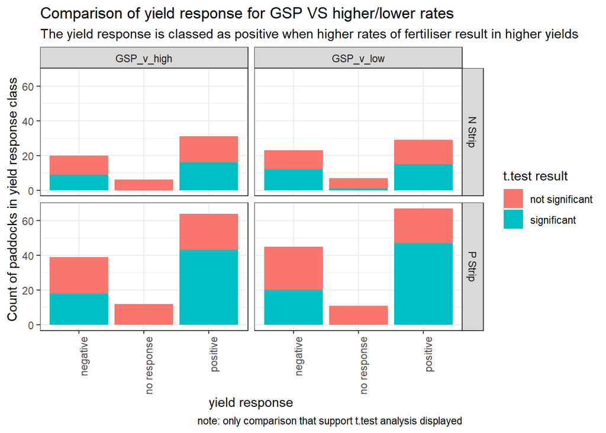

### GSP vs higher fertiliser rates

| Zone ID | Strip_Type | Mean yield difference | yield response | Significant | GSP rate | higher than GSP rate |
| --- | --- | --- | --- | --- | --- | --- |
| 311110 | P Strip | 0.32 | negative | significant | 50 | 120 |
| 311111 | P Strip | 0.62 | negative | significant | 50 | 120 |
| 311150 | N Strip | 0.49 | positive | significant | 30 | 40 |
| 311151 | N Strip | 0.13 | positive | significant | 30 | 40 |
| 311230 | N Strip | 2.27 | positive | significant | 270 | 440 |
| 311231 | N Strip | 1.31 | positive | significant | 270 | 440 |
| 311330 | P Strip | 0.57 | positive | significant | 70 | 140 |
| 311331 | P Strip | 0.26 | positive | not significant | 70 | 140 |
| 311360 | N Strip | 0.10 | negative | not significant | 200 | 300 |
| 311361 | N Strip | 0.12 | no_response | not significant | 200 | 300 |
| 312110 | P Strip | 0.44 | positive | significant | 35 | 70 |
| 312111 | P Strip | 0.14 | positive | not significant | 35 | 70 |
| 312140 | P Strip | 0.05 | negative | not significant | 35 | 70 |
| 312141 | P Strip | 0.26 | negative | significant | 35 | 70 |
| 312150 | N Strip | 0.17 | negative | significant | 80 | 160 |
| 312151 | N Strip | 0.09 | positive | not significant | 80 | 160 |
| 312160 | P Strip | 0.17 | negative | not significant | 35 | 55 |
| 312161 | P Strip | 0.02 | no_response | not significant | 35 | 55 |
| 312220 | N Strip | 0.74 | negative | significant | 60 | 120 |
| 312221 | N Strip | 0.11 | negative | not significant | 60 | 120 |
| 312230 | P Strip | 0.57 | positive | significant | 50 | 100 |
| 312231 | P Strip | 0.44 | positive | significant | 50 | 100 |
| 312240 | P Strip | 0.10 | positive | not significant | 35 | 60 |
| 312241 | P Strip | 0.24 | negative | significant | 35 | 60 |
| 316110 | P Strip | 0.03 | negative | not significant | 60 | 120 |
| 316111 | P Strip | 0.04 | negative | not significant | 60 | 120 |
| 316120 | N Strip | 0.12 | positive | significant | 60 | 120 |
| 316121 | N Strip | 0.03 | negative | not significant | 60 | 120 |
| 316210 | P Strip | 0.12 | negative | not significant | 70 | 105 |
| 316211 | P Strip | 0.37 | negative | significant | 70 | 105 |

[output cut: 142 more lines]

### GSP vs lower fertiliser rates

| Zone ID | Strip_Type | Mean yield difference | yield response | Significant | GSP rate | lower than GSP rate |
| --- | --- | --- | --- | --- | --- | --- |
| 311220 | P Strip | 0.35 | negative | not significant | 80 | 40 |
| 311221 | P Strip | 0.19 | negative | not significant | 80 | 40 |
| 311230 | N Strip | 2.92 | negative | significant | 270 | 185 |
| 311231 | N Strip | 1.44 | negative | significant | 270 | 185 |
| 311330 | P Strip | 0.30 | positive | significant | 70 | 35 |
| 311331 | P Strip | 0.68 | positive | significant | 70 | 35 |
| 311360 | N Strip | 0.31 | positive | significant | 200 | 100 |
| 311361 | N Strip | 0.18 | no_response | significant | 200 | 100 |
| 311520 | P Strip | 0.05 | negative | not significant | 50 | 25 |
| 311521 | P Strip | 0.75 | positive | significant | 50 | 25 |
| 312110 | P Strip | 0.09 | positive | not significant | 35 | 0 |
| 312111 | P Strip | 0.06 | positive | not significant | 35 | 0 |
| 312140 | P Strip | 0.19 | positive | significant | 35 | 15 |
| 312141 | P Strip | 0.36 | positive | significant | 35 | 15 |
| 312150 | N Strip | 0.27 | positive | significant | 80 | 40 |
| 312151 | N Strip | 0.08 | negative | not significant | 80 | 40 |
| 312160 | P Strip | 0.04 | positive | not significant | 35 | 20 |
| 312161 | P Strip | 0.07 | positive | not significant | 35 | 20 |
| 312220 | N Strip | 0.55 | positive | significant | 60 | 30 |
| 312221 | N Strip | 0.21 | positive | not significant | 60 | 30 |
| 312230 | P Strip | 0.88 | negative | significant | 50 | 25 |
| 312231 | P Strip | 0.84 | positive | significant | 50 | 25 |
| 312240 | P Strip | 0.39 | positive | significant | 35 | 20 |
| 312241 | P Strip | 0.50 | positive | significant | 35 | 20 |
| 316110 | P Strip | 0.22 | negative | significant | 60 | 30 |
| 316111 | P Strip | 0.13 | negative | not significant | 60 | 30 |
| 316210 | P Strip | 0.02 | negative | not significant | 70 | 30 |
| 316211 | P Strip | 0.34 | positive | significant | 70 | 30 |
| 317110 | N Strip | 0.57 | positive | significant | 100 | 0 |
| 317111 | N Strip | 0.22 | negative | significant | 100 | 0 |

[output cut: 152 more lines]

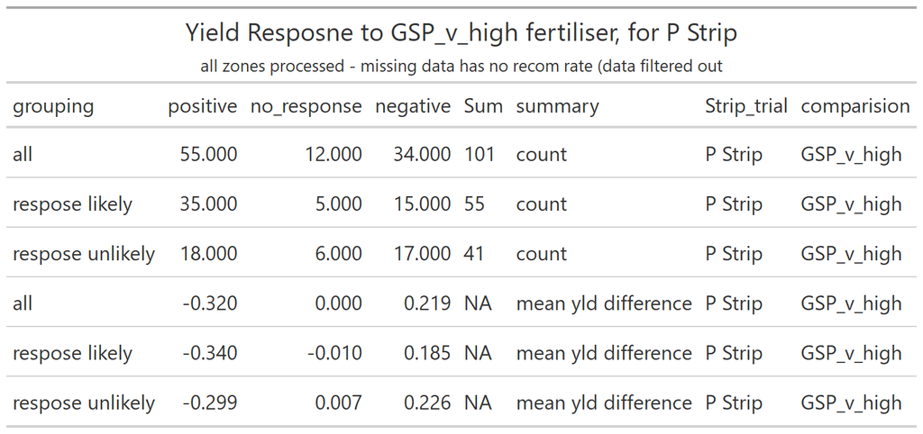

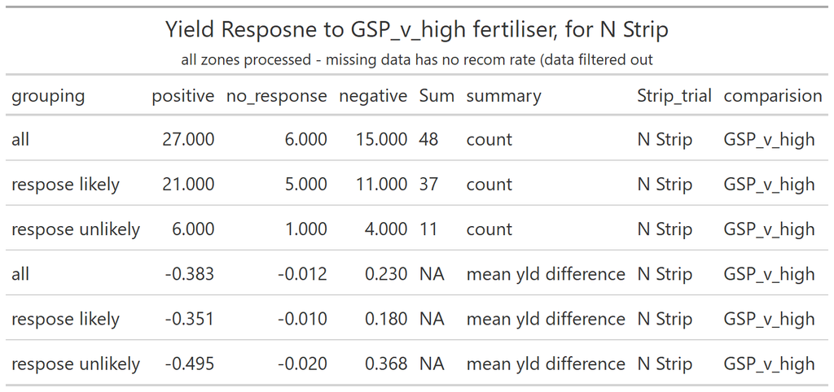

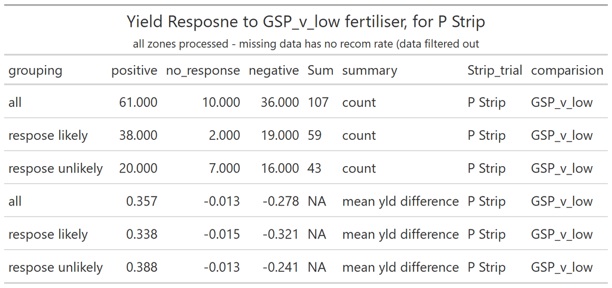

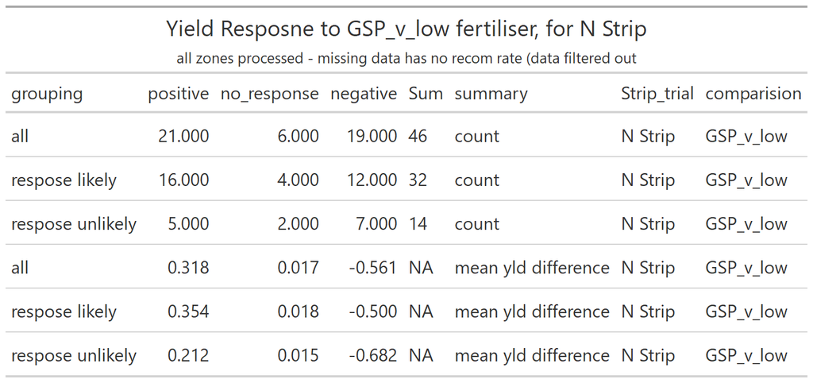

## Yield response to fertilisers application (recommended rates compared to other rates)

I have not done this yet and Sean is still working on the N rates. I will need to add this analysis to the t-test analysis I assume the approach will be similar to the above comparisons.

I will need to make a approx recommended rate. For this I will use the recommended rate and evaluate which rate that was implemented was the closest. A = recommend rate - abs(rate 1) B = recommend rate - abs(rate 2) C = rate - abs(rate 3)

then work out which has the smallest value A, B or C, this will be the approx recommended rate.

Then I will hopeful assign a rate lower than recommend rate and a rate higher than recommend rate.

Comparison of yield response in the strip / zone per paddock between:

- Approx recommend rate vs low fertiliser rate (yield for app rec fertiliser rate - yield for low fertiliser rate)
- Approx recommend rate fertiliser rate vs high fertiliser rate (yield for app rec fertiliser rate - yield for high fertiliser rate)

**More To come**

## Translating the Yield response to GM

I have all the elements to do this (I hope). The file is called “step4a_results_for_economics.csv”

Located here… "W:_soil_testing_prj_data\2020_files4a_results_for_economics.csv"

**Again more To come**